# Analyses of Flights Data

# Overview

The dataset gives us information about delayed flights for three years: 1992,2000 and 2008. We have a breakdown available including reason for delay, duration of delay and the origin/destination airport.

## Delay times distribution

The total number of delays has increased, and the distribution has got less skewed over the years as flights are delayed for longer

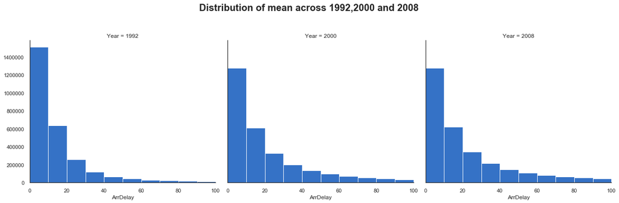

```python
#create a histogram to check the distribution of mean across the different years
g = sns.FacetGrid(data_clean, col='Year', margin_titles = True, height = 6)
g.map(plt.hist, 'ArrDelay',color = base_color, bins= bin_list)
g.fig.subplots_adjust(top=0.8)
g.fig.suptitle('Distribution of mean across 1992,2000 and 2008', fontsize = 20, weight = 'bold')
plt.xlim(0,100);
```

We can look at the statistics in more detail with a box plot

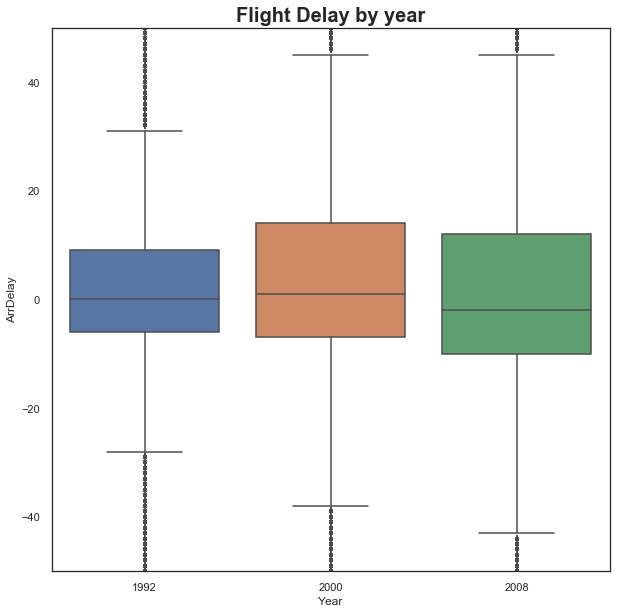

```python
# A boxplot to show how the spectrum has got wider of the delay times, and how we have more flights in the
# interquartile range
ax = sns.boxplot(y="ArrDelay", x='Year', data= data_clean)
plt.ylim(-50,50)
plt.title('Flight Delay by year', fontsize = 20, weight = 'bold');
```